# Object-oriented scientific programming with C++

Matthias Möller, Jonas Thies, Cálin Georgescu, Jingya Li (Numerical Analysis, DIAM)

Lecture 1

# What's this course about?

1. Principles of **object oriented programming** (not restricted to C++)
2. Principles of **scientific programming** (also not restricted to C++)
3. C++ 11, 14, 17, 20 and some of 23, not C++ 03 and before

# Object oriented programming

Using LEGO blocks as an analogy, you can think of object-oriented programming (OOP) as a way of building complex structures (programs) by piecing together different types of blocks (objects). These are the main concepts of OOP

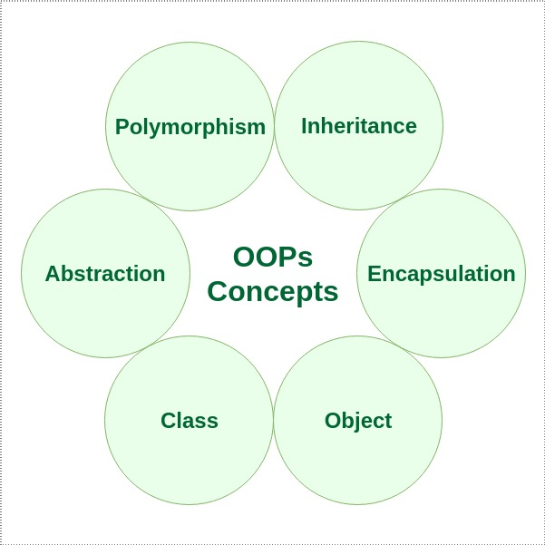

# A first example of OOP concepts

[output not shown]

# Course information

- **Lectures** (nonobligatory)
  - weeks 2.1-2.8, Wed 13:45-15:45 in lecture hall Ampere
- **Lab sessions** (nonobligatory)
  - weeks 2.2-2.8, Tue 8:45-12:45 (IDE Ctrl+Enter)
  - this is the time and place to ask your questions (no office hours! no reply to emails! no reply to discussion forums!)
- **WebLab** (https://weblab.tudelft.nl/tw3720tu-wi4771tu/2025-2026)
  - all demos, self-study exercises, computer exam and the final projects are provided via WebLab
  - weekly demos and self-study exercises become available on Monday morning
  - final projects become available in the week before Christmas and must be submitted by the end of Q2 via WebLab
- **Assessment** (3 ECTS)
  - weekly **self-study exercises** (formative feedback, no grade)
  - 3h **individual closed-book computer exam** on 16 December 2025 (40% of the grade)
  - final project can be worked on in **groups of 1-3 students** (60% of the grade)
- **Evaluation: self-study exercises**
  - programming exercises are checked against **full unit tests**; you can submit at any time and as often as you wish and receive immediate feedback
  - open questions are checked by TAs after the submission deadline; you get feedback within one week
- **Evaluation: computer exam**
  - programming assignments are checked against **full unit tests**; you can submit as often as you wish and receive immediate feedback; the grade is calculated by the percentage of passed unit tests
  - open questions are checked by examiners based on answer models after the exam
- **Evaluation: final project**
  - programming assignments are checked against **preliminary unit tests during the exam**; you can submit as often as you wish and receive immediate feedback if your implementation meets the specifications (*check that your code is callable*)
  - programming assignments are checked against **full unit tests after the exam**; your grade is determined by the percentage of passed unit tests (*check that your code functions correctly*)
  - open questions are checked by examiners based on answer models after the deadline
- **Unit tests**
  - don’t try to reverse engineer the unit tests! Focus on writing correct code instead
  - don’t ask us to write the unit tests so that they tell you which line of your code needs to be changed and how!
  - write your code according to **all** requirements of the assignment, especially adhere to the given interfaces
  - test your code carefully and think about corner cases, e.g., math-operations between different data types
  - if you cannot find the error **ask us** during the lab sessions
- **Fraud**
  - It is **prohibited to distribute the material** in full or in parts in any form (printed and electronically). This, in particular, prohibits the transfer of the material to webservices like Bitbucket, GitHub, Gitlab, etc. and the making available of solutions to the final project. This action is considered piggybacking and will be treated as fraud.
  - It is **not forbidden to use ChatGPT or Co-Pilot** as a source of inspiration. However, you must understand the code you submit and you must be able to explain your code when asking for help from TAs. Questions like "*This is what ChatGPT came up with, can you make it pass the unit tests?*" will not be answered.
  - The computer exam will be in **closed-book** style, i.e. no internet connection

# After all formalities ...

- ... ENJOY the course, I did so in all the years
- ... LEARN to write good C++ code
- ... DARE to think out-of-the-box
- ... ASK questions, I and my TAs are happy to answer them

Let’s get started with the fun part

# Programming languages

- A **computer programming language** is a formal notation (set of instructions) for writing computer programs
- One distinguishes between
  - **Interpreted languages** like Python, JavaScript, ...
  - **Compiled languages** like C, C++, Fortran, Julia, ...
- Another distinction is between
  - **Functional programming** that treats computation as evaluation of math functions
  - **Object-oriented programming** that treats computation as living objects that have mutable data and provide methods to manipulate the data

# Pros and Cons of *interpreted* languages

**Python**: Hello.py

```
1  a = 1
2  b = 2+a
3  c = 3+b
4
5  for i in range(b, 3+b):
6    a = a+1
7
8  print(c)
```

- Processes the code line by line at run time (slow!) 😭
  - Computes `3+b` twice (in lines 3, 5) 😭
  - Cannot know **in advance** that lines 5-6 are not 'used' at all 😭
  - Cannot reorder code 😭
- Can inject/load new code instructions at run time 😀
- Platform independent 😀
- Dynamic or no typing 😀 / 😭

# Pros and Cons of *compiled* languages

**C++**: Hello.cxx

```
1  int a = 1;
2  int b = 2+a;
3  int c = 3+b;
4
5  for (int i=b; i<=3+b; i++)
6    a + a+1
7
8  printf("%d\n", c);
```

# Example of a *compiled* language

**C++**: Hello.cxx

```
1  int a = 1;
2  int b = 2+a;
3  int c = 3+b;
4
5  for (int i=b; i<=3+b; i++)
6    a + a+1
7
8  printf("%d\n", c);
```

Compilation by hand

```
g++ -O0 --save-temps Hello.cxx -o Hello.exe
```

yields the following files

- `Hello.i` contains `#includes` (later!)
- `Hello.s` is the assembly code (text)
- `Hello.o` is the object file (binary)
- `Hello.exe` is the executable (binary)

Running the executable

```
./Hello.exe
```

outputs `6`

# Let’s get started

- Live demo in WebLab: https://weblab.tudelft.nl/tw3720tu-wi4771tu/2025-2026/
- Where to find information on C++
  - A Tour of C++: https://isocpp.org/tour
  - CPlusPlus: http://www.cplusplus.com
  - Geeks for Geeks: https://www.geeksforgeeks.org/c-plus-plus/

# Class vs. Object

Once again in LEGO terms ...

A **class is a blueprint**, aka an instruction manual that tells you how to create something

An **object** is a living instance created (instantiated) from the class blueprint

[figure not shown]

vs.

[figure not shown]

Let's start with the following example, and learn everything (first two weeks) by filling in this example

```
// The class. Recommendation: use // for single line comments
class MyFirstClass { // ... and also at the end of a code line
};

int main() {
  /**
   * Recommendation: use this syntax for multiline comments
   * for multiline comments
   */
  MyFirstClass myObj;  // Create an object of MyFirstClass
  return 0;
}
```

# Hello World!

```
// Include header file for standard input/output stream library
#include <iostream>

// The global main function that is the designated start of the program
int main(){
  /**
    * Write the string 'Hello world!' to the default output stream and
    * terminate with a new line (that is what std::endl does)
    */
  std::cout << "Hello world!" << std::endl; // or “Hello world!\n”;
  return 0; // Return code 0 to the operating system (=no error)
}
```

This can also be done by using a **class**

```
// HelloWorld class
class HelloWorld {
    public:
    void PrintHelloWorld() // public member function
    {
        std::cout << "Hello World!\n";
    }
};

int main(){
    HelloWorld hello; // create an object of HelloWorld
    hello.PrintHelloWorld(); // call member function
}
```

Extra functionality provided by the standard C++ library is defined in so-called **header files** which need to be included via

```
#include <headerfile>
```

Some useful header files are

- `iostream` : input/output
- `string` : string types
- `complex` : complex numbers
- Good overview: http://www.cplusplus.com

We will write our own header files later in this course as well

# OOP style and member function

Function that computes the sum of a Vector

```
double sum(const Vector& v) {
  double s = 0;
  for (auto i = 0; i < v.length; i++)
    s += v.array[i];
  return s;
}
```

This is **NOT** really OOP-style!

```
int main() {
  Vector x = { 1, 2, 3, 4, 5 };
  std::cout << sum(x) << std::endl;
}
```

The member function version

```
class Vector {
  public:
  double sum() {
    double s = 0;
    for (auto i=0; i<length; i++)
      s+=array[i];
    return s;
  }
}
```

This is a **GOOD** OOP-style!

```
int main() {
  Vector x = {1,2,3};
  std::cout << x.sum() << std::endl;
}
```

We will get back to this topic later

# THE main function

Now let's only focus on the `main` function

- Each C++ program must provide one (and only one!) global **main function** which is the designated start of the program

  ```
  int main() { body }
  ```

  or

  ```
  int main(int argc, char* argv[]) { body }
  ```

  - **Scope** of the main function is `{ ... }`
  - **Return type** of the main function is `int` (=integer), e.g., `return 0;`
  - Main function cannot be called recursively

# Standard output

Stream-based output system

```
#include <iostream>

std::cout << "Hello world!" << std::endl;
```

```
Hello world!
```

Streams can be easily concatenated

```
std::cout << "Hello" << " " << "world!" << std::endl;
```

```
Hello world!
```

Streams are part of the standard C++ library and therefore encapsulated in the **namespace** `std`; instead of using `std::` one can also import **all** functionality from the namespace by

```
using namespace std;
cout << "Hello world!" << endl;
```

```
Hello world!
```

Predefined output streams

- `std::cout` : standard output stream
- `std::cerr` : standard output stream for errors
- `std::clog` : standard output stream for logging

# Variables and constants

C++ is **case sensitive** and **typed**, that is, variables and constants have a **value** and a **concrete type**

```
int a = 10; // create integer variable and initialize it to 10
a = 15;     // update the value of integer variable to 15
```

```
15
```

**Variables** can be updated, **constants** cannot

```
const int b = 20; // create integer constant and initialize it to 10

a = b;
b = a;
```

```
input_line_15:4:3: error: cannot assign to variable 'b' with const-qualified type 'const int'
b = a;
~ ^
input_line_15:2:12: note: variable 'b' declared const here
 const int b = 20; // create integer constant and initialize it to 10
 ~~~~~~~~~~^~~~~~
```

```
Interpreter Error:
```

# Initialization of constants

**Constants** must be initialized during their **definition**

```
const int c = 20;   // C-like initialization
const int d(20);    // constructor initialization
const int e = {20}; // uniform initialization, since C++11
const int f{20};
```

# Initialization of variables

**Variables** can be initialized during their **definition** or (since they are variable) at any location later in the code

```
int g = 10;   // C-like initialization
int h(20);    // constructor initialization
int i = {20}; // uniform initialization, since C++11
int j;        // only declaration (arbitrary value!)
j = 20;       // assignment of value
```

```
20
```

# Intermezzo: Terminology

- A **declaration** introduces the name of the variable or constant, and describes its type but does not create it

  ```
  extern int f;
  ```

- A **definition** instantiates it (=creates it)

  ```
  int f;
  ```

- An **initialization** initializes it (=assigns a value to it)

  ```
  f = 10;
  ```

- All three steps can be combined, e.g., `int f{10}` or split across different source/header files (later in this course)

# Scope of variables/constants

Variables/constants are only visible in their **scope**

```
int main() {
    int a = 10;  // variable a is visible here

    {
      int b = a; // variable a is visible here
    }

    {
      int c = b; // variable a is visible here, b is not(!) visible here -> error
    }
}
```

Another example

```
int main() {
    int a = 10;   // variable a is visible here

    {
      int a = 20; // new variable a only visible in blue
                  // scope, interrupts scope of red one
      std::cout << a << std::endl; // is 20
    }

    std::cout << a << std::endl;   // is 10
}
```

# C++ standard types

| Group | Type name | Notes on size / precision |
| --- | --- | --- |
| Character types | `char` | Exactly one byte in size. At least 8 bits. |
|  | `char16_t` | Not smaller than char. At least 16 bits. |
|  | `char32_t` | Not smaller than char16_t. At least 32 bits. |
| Integer types (signed and unsigned) | `(un)signed char` | Same size as char. At least 8 bits. |
|  | `(un)signed short int` | Not smaller than char. At least 16 bits. |
|  | `(un)signed int` | Not smaller than short. At least 16 bits. |
|  | `(un)signed long int` | Not smaller than int. At least 32 bits. |
|  | `(un)signed long long int` | Not smaller than long. At least 64 bits. |
| Floating-point type | `float` | Precision not less than float |
|  | `double` | Precision not less than float |
|  | `long double` | Precision not less than double |
| Boolean type | `bool` |  |

# Examples of C++ types

Double-precision floating-point type

```
double d1 = 1.0;
double d2 = 1.;    // zero is added automatically
double d3 = 1e3;   // -> 1000
double d4 = 1.5E3; // -> 1500
double d5 = 15e-2; // -> 0.15
```

Single-precision floating-point type

```
float f1 = 1.0f;   // or 1.0F suffix type specifier
float f2 = 1.0;    // works the same but does conversion
float f3 = 1.5e3F; // -> 1500
```

# Mixing and conversion of types

Getting the **type** of a variable

```
#include <typeinfo>

float f = 1.7f; double d = 0.7;
std::cout << typeid(f).name() << std::endl; // float
std::cout << typeid(d).name() << std::endl; // double
```

```
f
d
```

```
@0x7f128339fde0
```

C++ converts different types automatically

```
std::cout << typeid(f + d).name() << std::endl; // double
```

```
d
```

```
@0x7f128339fde0
```

Check if you are happy with the result

```
char  x = 'a';
float y = 1.7;
std::cout << typeid(x + y).name() << std::endl; // float???
```

```
f
```

```
@0x7f128339fde0
```

C++11 introduces the `auto` keyword, which makes handling of mixed types very easy

```
auto x = f + d;
std::cout << typeid(x).name() << std::endl; // double
```

```
d
```

```
@0x7f128339fde0
```

You can also explicitly **cast** one type into another

```
auto y = f + (float)d;
std::cout << typeid(y).name() << std::endl; // float

auto z = (int) (f + (float)d);
std::cout << typeid(z).name() << std::endl; // int
```

```
f
i
```

```
@0x7f128339fde0
```

# auto vs. explicit types

- **Recommendation:** use the keyword `auto`
  - to improve readability of the source code
  - to improve maintainability of the source code
  - to benefit from performance gains (later in this course)
- ... unless explicit conversion is required
  - `auto a = 1.5+0.3;` is the same as `(double)1.8 = 1.8`
  - `int b = 1.5+0.3;` is the same as `(int)1.8 = 1`
- ... unless the C++ standard does not allow so, e.g., return type of a (pure) virtual function (later in this course)

# Use of suffix type specifiers

- **Suffix type specifiers** (termed **literals**) seem unnecessary at first glance since constants are implicitly converted

  ```
  float f1 = 0.67;
  ```

- But keep in mind that `0.67` and `0.67f` are not the same

  ```
  std::cout << (f1 == 0.67);  // -> false
  std::cout << (f1 == 0.67f); // -> true
  ```

```
float f1 = 0.67;
std::cout << (f1 == 0.67);
std::cout << (f1 == 0.67f);
```

```
01
```

# Address-of/dereference operators

- Integer **variable**

  ```
  int i = 10;
  ```

- **Pointer** to its address

  ```
  auto p = &i;
  ```

- **Dereference** to its value

  ```
  int j = *p;
  ```

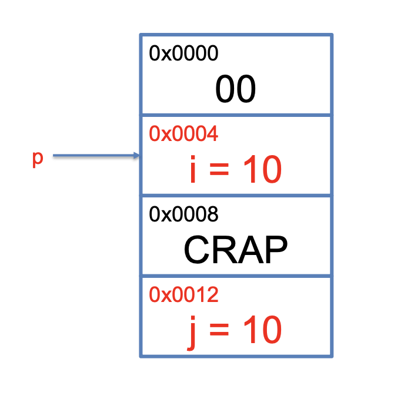

```
int  i = 10;
auto p = &i;
int  j = *p;
```

**Address-of operator** (`&`): returns the address of a variable (= its physical location in the computer’s main memory)

```
std::cout << i << std::endl;
std::cout << p << std::endl;
```

```
10
1
```

Addresses are of **pointer** type (equal to that of the variable)

```
std::cout << typeid(i).name() << std::endl; // -> i
std::cout << typeid(p).name() << std::endl; // -> Pi
```

```
i
Pi
```

```
@0x7f128339fde0
```

**Dereference operator** (`*`): returns the value behind the pointer (= the value stored at the physical location in the computer's main memory)

```
std::cout <<  i << std::endl;
std::cout << *p << std::endl;
```

```
10
10
```